# Week 7: Matching

PS 813 - Causal Inference

Anton Strezhnev

strezhnev@wisc.edu

University of Wisconsin-Madison

March 1, 2027

$$\require{cancel}$$

## Last week

- **Regression** adjustment for estimation of effects under **conditional ignorability**
  - Build a model for $\mathbb{E}[Y_i | X_i , D_i = d]$
  - Average over the predictions to get $\hat{\mathbb{E}}[Y_i(1)] = \frac{1}{N}\sum_{i=1}^N \hat{\mathbb{E}}[Y_i | X_i , D_i = 1]$
- **Weighting** adjustment using inverse-propensity weighting
  - Build a model for $e(X_i) = P(D_i = 1 | X_i)$
  - Re-weight to get $\hat{\mathbb{E}}[Y_i(1)] = \frac{1}{N} \sum_{i=1}^N \frac{Y_iD_i}{\hat{e}(X_i)}$
- **Combining** the two approaches - **Augmented Inverse Propensity Weighting** (AIPW)
  - “Double-robustness” - Need only **one** of the two models to be consistent for the true CEF/propensity score

## This week

- What if we don’t want to make **any** model assumptions?
  - Even with **two** chances at the model with AIPW, we might be concerned about misspecification error
- One solution is to use **matching**
  - **Intuition**: What’s our best guess for $Y_i(0)$ for a unit with $D_i = 1$ and $X_i = x$?
  - Ideally, we’d use $Y_i$ for a unit with $D_i = 0$ and $X_i = x$.
  - If we can’t find one with $X_i = x$…find one with the **closest** $X_i$ to $x$.
- Challenges of **matching**
  - What’s the right way to measure “close” vs. “far”?
  - How far is too far?
  - What do we do about the residual differences?

## Review: Imputation estimators

- We want to estimate the sample average treatment effect

  $$\tau = \frac{1}{N}\sum_{i=1}^N Y_i(1) - Y_i(0)$$
- Many estimators $\hat{\tau}$ can be written as differences in **imputed** potential outcomes

  $$\hat{\tau} = \frac{1}{N} \sum_{i=1}^N \widehat{Y}_i(1) - \widehat{Y}_i(0)$$
- Previously, we used **regression** to generate the imputations
  - Use a linear regression model $\hat{E}[Y_i | X_i, D_i = 1] = X_i^\prime\hat{\beta}^{(1)}$ to impute $\widehat{Y}_i(1)$
  - Use a linear regression model $\hat{E}[Y_i | X_i, D_i = 0] = X_i^\prime\hat{\beta}^{(0)}$ to impute $\widehat{Y}_i(0)$

## Matching estimators

- An alternative approach is to use some notion of “closeness” to impute the potential outcomes.

  $$\hat{\tau} = \frac{1}{N} \sum_{i=1}^N \widehat{Y}_i(1) - \widehat{Y}_i(0)$$
- For unit $i$, if it’s **treated** ($D_i = 1$)…
  - …impute $Y_i$ for $\widehat{Y}_i(1)$
  - …impute $Y_j$ for $\widehat{Y}_i(0)$…
  - …where $j$ is another unit with $D_j = 0$ and $X_i \approx X_j$
- Vice-versa for the **control** units.

## Matching estimators

- **Central question**: How do we decide what “close” means?
- We need to chhoose a **distance metric**
  - Let $Q_{ij}$ denote the distance between the covariates $X_i$ and $X_j$ between units $i$ and $j$
- Common metrics:
  - *Exact*: $Q_{ij} = 0$ if $X_i = X_j$ and $Q_{ij} = \infty$ if $X_i \neq X_j$
  - *Standardized Euclidean*:

    $$Q_{ij} = \sqrt{\sum_{k=1}^K \frac{(X_{ik} - X_{jk})^2}{s_k^2}}$$
  - **Most common:** *Mahalanobis*:

    $$Q_{ij} = \sqrt{(X_i - X_j)^{\prime}S^{-1}(X_i - X_j)}$$

    where $S$ is the sample variance-covariance matrix.

## Matching estimators

- Once we have a **distance metric**, we still need to choose..
  - …how many units should we match (1-to-1, 1-to-3, 1-to-10, etc…)?
- Should the matching be done **with** replacement or **without** replacement?
  - **With replacement** - once matched, units can be **re-used** and matched with other units.
  - **Without replacement** - matched units fall out of the matching pool once used.
- We’ll analyze the case for matching **with** replacement
  - Order of matching doesn’t matter
  - We always pick the closest units (so matching discrepancy is minimized)
  - Higher variance - (e.g. if only one treated unit is close to many controls).

## Nearest-neighbor matching

- For a treated unit with $D_i = 1$, we impute the potential outcomes as:

  $$\widehat{Y}_i(1) = Y_i$$

  $$\widehat{Y}_i(0) = \frac{1}{M} \sum_{j \in \mathcal{J}_M(i)} Y_j$$

  where $\mathcal{J}_M(i)$ is the set of $M$ closest matches to $i$ among the control observations.
- Do the same for the controls (but impute $\widehat{Y}_i(1)$ using matched treated units)
- We can think of matching as a kind of weighting estimator that assigns a weight of $1 + \frac{K_M(i)}{M}$ to each unit.

  $$\hat{\tau^m_M} = \frac{1}{N}\sum_{i=1}^N (2D_i -1) \bigg(1 + \frac{K_M(i)}{M}\bigg) Y_i$$

## ATE or ATT?

- In many settings where we might want to use matching, we have a handful of treated units and many controls.
  - Easy to find a good match for each treated unit
  - *Hard* to find a good match for each control.
- So instead of trying to estimate the ATE, we could try to estimate the ATT instead - using the controls *only* to impute.

  $$\hat{\tau^m_{\text{ATT}}} = \frac{1}{N_t}\sum_{i: D_i = 1} Y_i - \widehat{Y_i(0)}$$
- In terms of the “matching weights”, this is equivalent to

  $$\hat{\tau^m_{\text{ATT}}} = \frac{1}{N}\sum_{i=1}^N \bigg(D_i - (1 - D_i)\frac{K_M(i)}{M}\bigg) Y_i$$
- ATT in an observational study is often the more policy-relevant quantity
  - e.g.: How were the incomes of people who *actually* received a particular social service improved?

## Properties of the simple matching estimator

- Unless matching is exact, **Abadie and Imbens (2006)** show that matching exhibits a bias.

  $$B_M = \frac{1}{N}\sum_{i=1}^N (2D_i - 1) \bigg[\frac{1}{M} \sum_{m=1}^M \mu_{1-D_i}(X_i) - \mu_{1-D_i}(X_{\mathcal{J}_m(i)})\bigg]$$

  where $\mu_1(X_i) = E[Y_i(1) | X_i]$ and $\mu_0(X_i) = E[Y_i(0) | X_i]$ are the CEFs of the two potential outcomes.
- **Intuitively** - the bias term captures the differences in the conditional expectation function between observation $i$’s covariates and the covariates of the $M$ matches in $\mathcal{J}_m(i)$.
  - When matching is exact, $X_i$ and all of the $X_j$s of the matched units are identical
  - When matching is inexact, we have this **matching discrepancy**
- But does this bias go away in large samples?
  - With many continuous covariates, not fast enough - the rate of convergence of the bias term is slower than that of the sampling variance (the simple matching estimator is not $\sqrt{n}$-consistent).
  - This means our asymptotic approximations for the variance will be poor even in large samples.

## Simulation to show the bias

- Let’s construct a simulation with confounding. Start with $K=8$ i.i.d. covariates $X_1, X_2, \dotsc X_K$ each distributed $\mathcal{N}(0,1)$.
- Treatment probability is modeled as a logit

  $$\text{log}\bigg(\frac{e(X_i)}{1-e(X_i)}\bigg) = \beta_1X_1 + \beta_2X_2 + \beta_3X_3 + \dotsc + \beta_k X_k$$
- We’ll assume the coefficients are $\beta_k = \frac{1}{k}$
- Outcome is linear w/ same coefficients $\beta_k$ and a constant treatment effect of $2$

  $$Y_i = 2D_i + \mathbf{X}\beta + \epsilon_i$$

## Simulation

- First, our unadjusted simple difference-in-means estimator

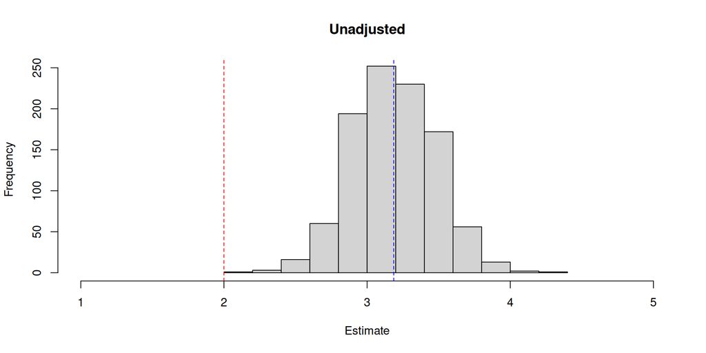

## Simulation

- Now, the 1-to-1 matching estimator

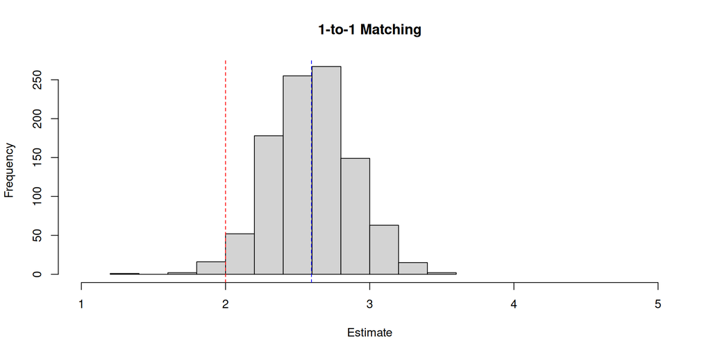

## Simulation

- How about 1-to-3 matching?

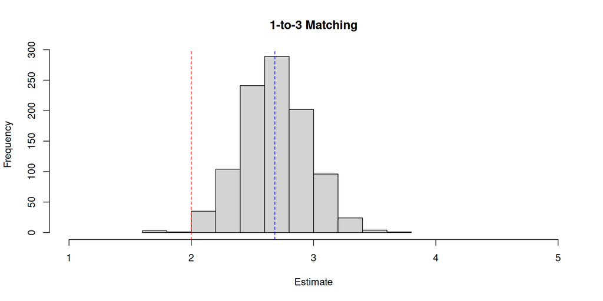

## Simulation

- Now, what if we estimate the bias correction (using a regression estimator)

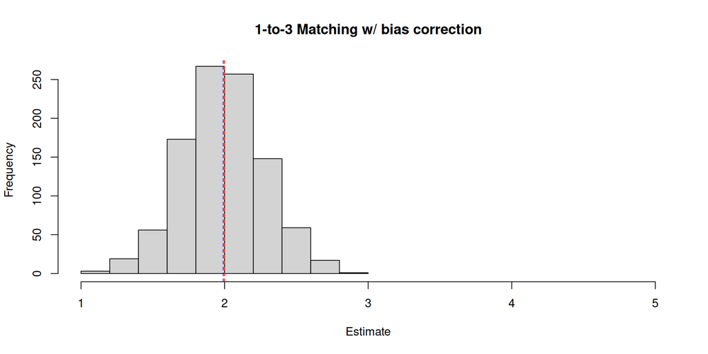

## Simulation to show the bias

- What if we just had 1 covariate?

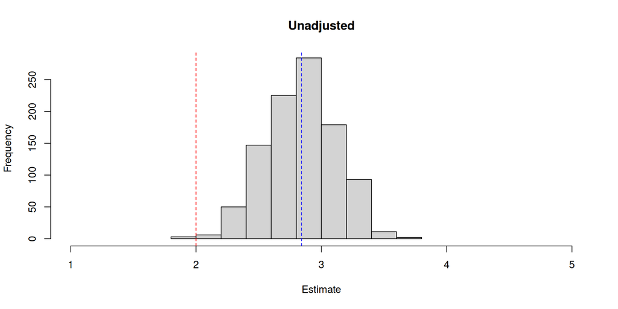

## Simulation to show the bias

- Matching bias is a **dimensionality** problem!

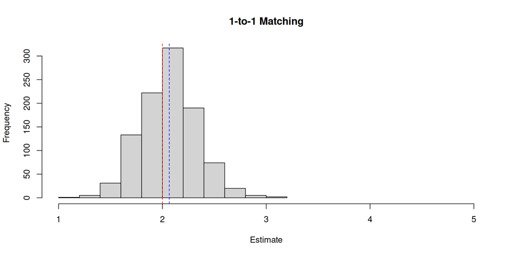

## Bias-corrected matching

- Instead of substituting in just the average in the matches, **Abadie and Imbens (2011)** propose a “bias-corrected” imputation
- For $D_i = 1$

  $$\widehat{Y}_i(1) = Y_i$$

  $$\widehat{Y}_i(0) = \frac{1}{M}\sum_{j \in \mathcal{J}_M(i)} (Y_j + \hat{\mu_0}(X_i) - \hat{\mu_0}(X_j))$$
- For $D_i = 0$

  $$\widehat{Y}_i(0) = Y_i$$

  $$\widehat{Y}_i(1) = \frac{1}{M}\sum_{j \in \mathcal{J}_M(i)} (Y_j + \hat{\mu_1}(X_i) - \hat{\mu_1}(X_j))$$
- **Intuition** – We combine regression and matching! Regression models adjust for the residual imbalance that matching doesn’t solve while matching helps limit the consequences of regression model misspecification.

## Matching as pre-processing

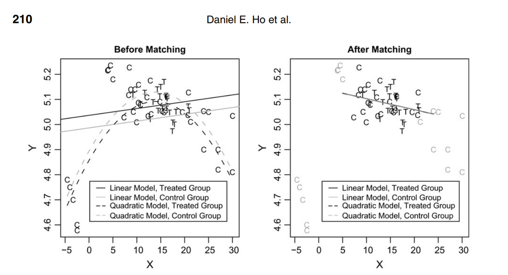

Ho, Daniel E., et al. “Matching as nonparametric preprocessing for reducing model dependence in parametric causal inference.” Political analysis 15.3 (2007): 199-236.

## Variance estimation

- **Abadie and Imbens (2008)** show that the standard pairs **bootstrap** doesn’t work well for variance estimation.
  - **Intuition**: The matching weights are not a **smooth** function of the inputs - it does not preserve the distribution of the match counts $K_M(i)$
- **Otsu and Rai (2017)** develop a **weighted** bootstrap using the residuals from the **linearized** version of the matching estimator
  - **Intuition**: Instead of resampling pairs $Y_i$ and $X_i$, we resample $\tilde{\tau}_i$ where…

  $$\hat{\tau} = \frac{1}{N}\sum_{i=1}^N (2D_i -1) \bigg(1 + \frac{K_M(i)}{M}\bigg) Y_i = \frac{1}{N}\sum_{i=1}^N \tilde{\tau}_i$$
- Alternatively, **Abadie and Imbens (2006)** derive the asymptotic variance and implement a matching estimator for the outcome variance terms.
  - `Matching` package implements this estimator.
- In the case of post-matching inference when matching **without replacement**, **Abadie and Spiess (2020)** show that matching induces dependence within matched sets
  - Solution: Clustered standard errors, clustered on matched set.

## Other matching methods

- A lot of other methods have been developed (primarily in the medicine/biostats literature) that are essentially extensions of matching **without replacement**
- *Optimal* matching
  - Minimize the **total distance** between treated and the set of chosen (matched) control units
  - Can improve over greedy “nearest-neighbor” matching when matching **without replacement**
- *Full* matching
  - Instead of matching 1-to-1 (or 1-to-many), create subclasses with at least 1 treated and control
  - Minimize the within-subclass distances (optimal matching)

## Other matching methods

- Other parts of the matching literature try tweaking the **distance** metric
- *Genetic* matching **(Diamond and Sekhon, 2013)**
  - Find the $S^{-1}$ matrix in the Mahalanobis distance that optimizes some criterion of balance between treated and control groups
  - Essentially trying to find optimal “weights” to put on covariates in the matching algorithm to achieve some global optimum of balance.
  - Use a “genetic” algorithm to search for this optimum (non-linear optimization problem)

## Example: Keele et. al. (2017)

- Read in the data

```r
turn <- haven::read_dta("assets/data/match-all.dta")
```

- Recall the simple difference-in-means

```r
lm_robust(black_turnout ~ black, data=turn)
```

```
            Estimate Std. Error t value  Pr(>|t|) CI Lower CI Upper   DF
(Intercept)     44.0      0.946   46.47 1.88e-252    42.12     45.8 1004
black            7.7      1.230    6.26  5.71e-10     5.28     10.1 1004
```

## Example: Keele et. al. (2017)

- Visualize the confounding!

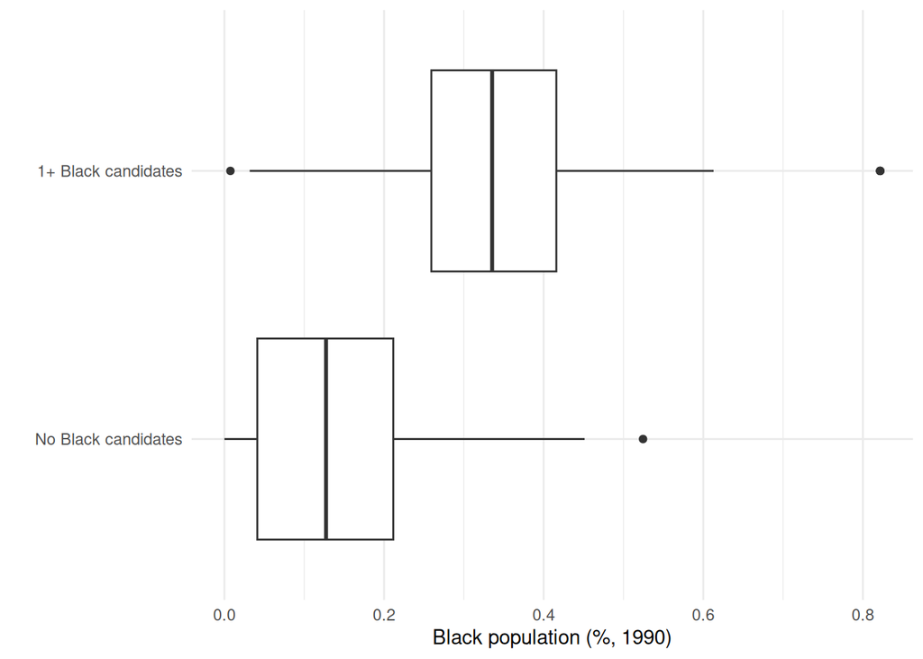

## Example: Keele et. al. (2017)

- Visualize the confounding!

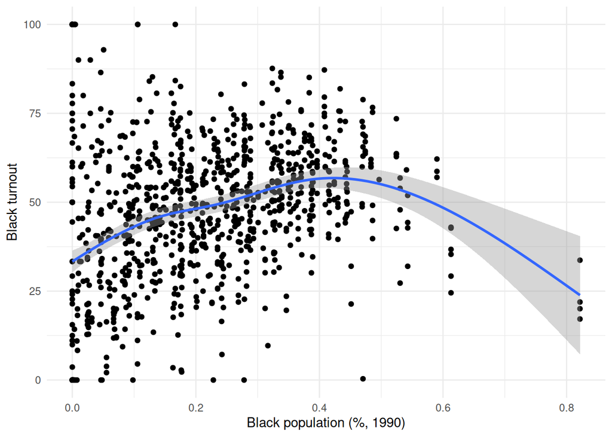

## Example: Keele et. al. (2017)

- **Design**: Selection-on-observables with lots of covariates to adjust for:
  - Population, pct. Black, pct. College degree, pct. High school, pct. Unemployed, median income, pct. below poverty line, home rule charter
- We’ll focus on replicating their matching approach for **general** election turnout.
  - They also look at **runoff** elections where they believe selection-on-observables is more plausible.
- We’ll use standard 1-to-1 nearest neighbor matching
  - The paper itself actually uses a variant of optimal matching

## Example: Keele et. al. (2017)

```r
match_results <- Matching::Match(Y = turn$black_turnout, Tr = turn$black,
                         X = turn %>% dplyr::select(year, pop90, blackpop_pct1990,
                                                    college_pct, hs_pct,
                                                    unemp, income, poverty, home),
                         M=1 , Weight = 2, estimand = "ATT")
                        # Weight = 2 = Mahalanobis distance
```

## Example: Keele et. al. (2017)

- Results

```r
summary(match_results)
```

```
Estimate...  0.48066
AI SE......  1.3318
T-stat.....  0.36093
p.val......  0.71815

Original number of observations..............  1006
Original number of treated obs...............  356
Matched number of observations...............  356
Matched number of observations  (unweighted).  371
```

## Example: Keele et. al. (2017)

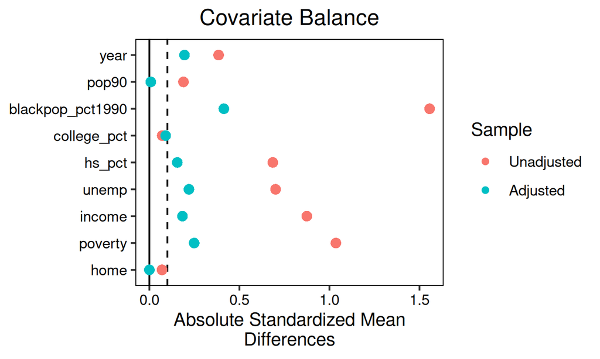

## Example: Keele et. al. (2017)

- What happens if we force **exact** matching on year?

```r
match_results2 <- Matching::Match(Y = turn$black_turnout, Tr = turn$black,
                         X = turn %>% dplyr::select(year, pop90, blackpop_pct1990,
                                                    college_pct, hs_pct,
                                                    unemp, income, poverty, home),
                         exact = c(T, F, F, F, F, F, F, F, F),
                         M=1 , Weight = 2, estimand = "ATT")
                        # Weight = 2 = Mahalanobis distance
```

## Example: Keele et. al. (2017)

- Results

```r
summary(match_results2)
```

```
Estimate...  5.698
AI SE......  1.4385
T-stat.....  3.9612
p.val......  7.4571e-05

Original number of observations..............  1006
Original number of treated obs...............  356
Matched number of observations...............  356
Matched number of observations  (unweighted).  358

Number of obs dropped by 'exact' or 'caliper'  0
```

## Example: Keele et. al. (2017)

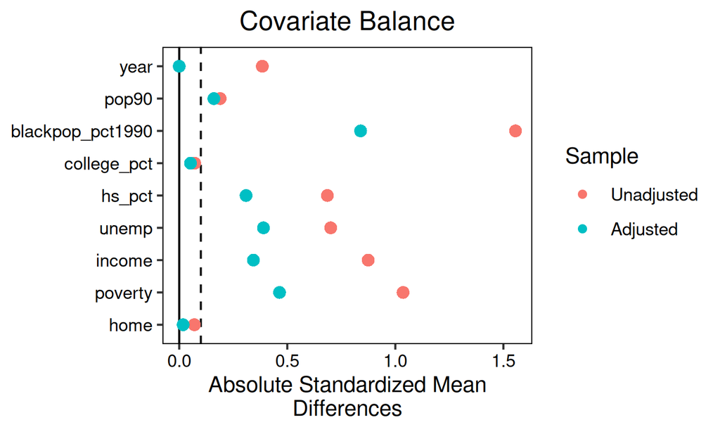

## Example: Keele et. al. (2017)

- Now, what if we add in the bias-correction (the regression)

```r
match_results_bc <- Matching::Match(Y = turn$black_turnout, Tr = turn$black,
                         X = turn %>% dplyr::select(year, pop90, blackpop_pct1990,
                                                    college_pct, hs_pct,
                                                    unemp, income, poverty, home),
                         exact = c(T, F, F, F, F, F, F, F, F),
                         M=1 , Weight = 2, estimand = "ATT", BiasAdjust = T)
                        # Weight = 2 = Mahalanobis distance
```

## Example: Keele et. al. (2017)

```r
summary(match_results_bc)
```

```
Estimate...  -1.028
AI SE......  1.5732
T-stat.....  -0.65343
p.val......  0.51348

Original number of observations..............  1006
Original number of treated obs...............  356
Matched number of observations...............  356
Matched number of observations  (unweighted).  358

Number of obs dropped by 'exact' or 'caliper'  0
```

## Summary

- Matching is a useful tool for reducing covariate imbalance between treated and control groups in a selection-on-observables design
  - **Intuition**: Group together treated and control units with “similar” covariate values
  - Does not depend on any model for the treatment or the outcome
- However, matching is not a universal panacea even if we buy selection-on-observables
  - Still have residual imbalance due to imperfect matches.
  - Matching in high-dimensional space is tricky.
- **Combining** matching and regression
  - Matching is commonly framed as a “pre-processing” step prior to regression to avoid regression imputations that are far from the data.
- At it’s core, matching is a tool for weighting the sample to improve **balance** between the treated and control groups.
  - But we could just target the **balance directly** rather than indirectly via distances…

## Next week

- How to deal with forms of **unobserved confounding**
- Our first approach - **Instrumental Variables**
  - What if **treatment** is not randomized…
  - …but an **instrument** is!
- We can identify (a particular type of) average treatment effect if…
  - The **instrument** only affects the outcome **through** its effect on the treatment!
- Where have we seen this before?
  - **Experiments** with **non-compliance**
  - **Treatment** = “taking the treatment”
  - **Instrument** = “being assigned to take the treatment”